# Novità

Ottavia

2022-11-10

# Figure già definite nel codice

## Torte e fette

Potenzialmente, alla singola fetta si può cambiare la dimensione e la rotazione (non riesco a farlo automaticamente)

Bisogna aggiungere una sfumatura di grigio per poter usare il filling

Singola fetta:

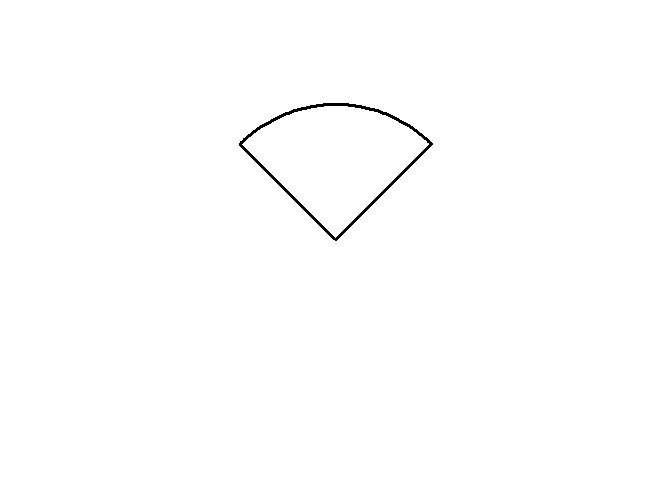

```r
draw(slice())
```

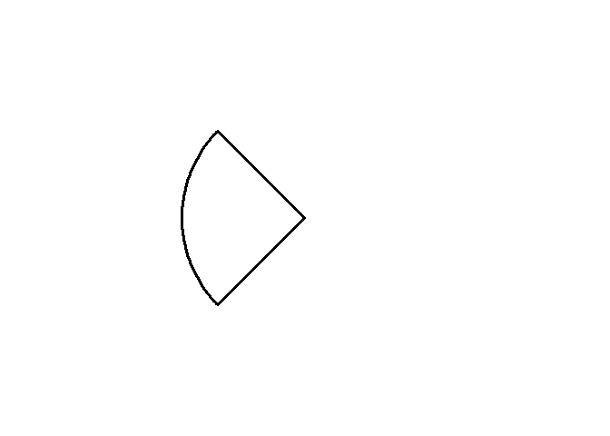

```r
draw(slice(theta1= 3*pi/4,
           theta2 = 5*pi/4))
```

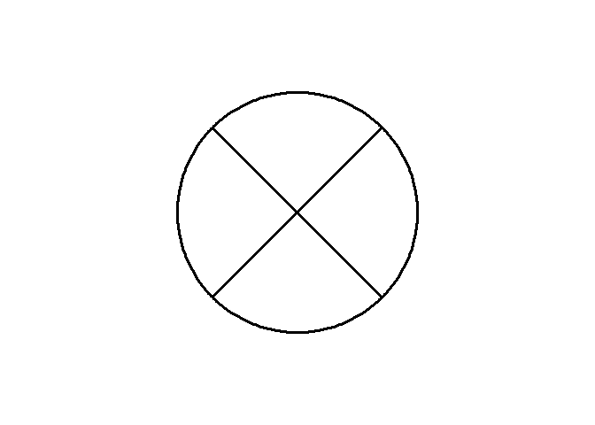

```r
draw(pie.4())
```

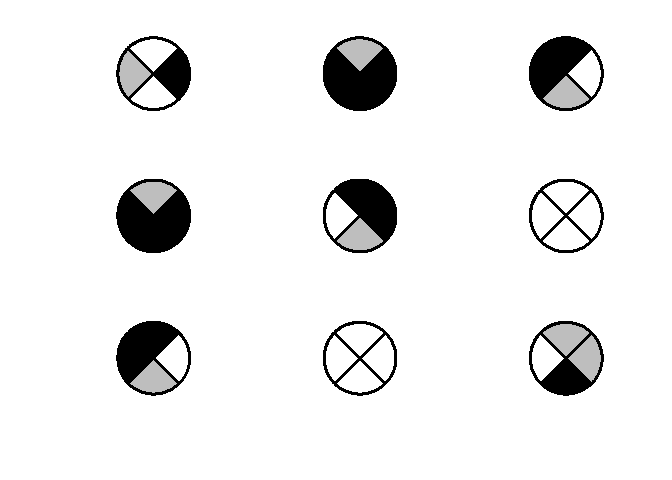

```r
M1<-apply(Raven(pie.4(),
                "multifill","multifill"))
draw(M1)
```

## Torte a metà

In questo caso ho definito 4 semi cerchi, i rispettivi cerchi sia come `compose4` sia come `simple`:

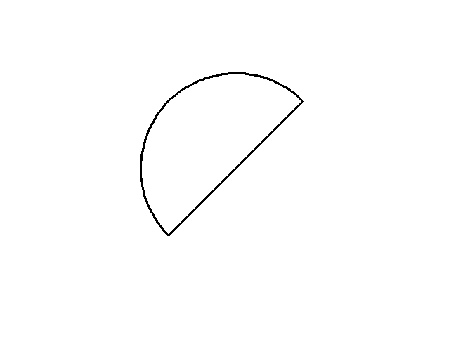

```r
draw(semi.circle())
```

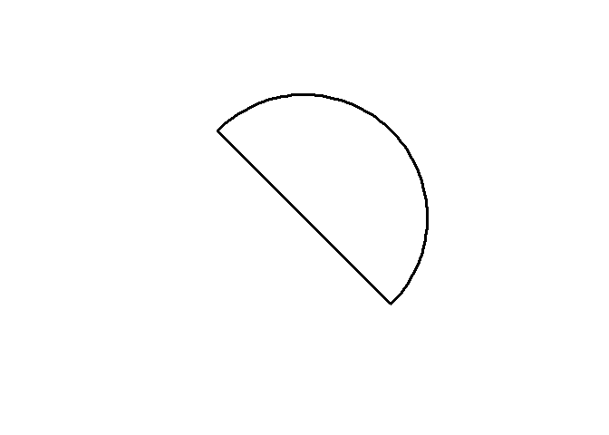

```r
draw(semi.circle1())
```

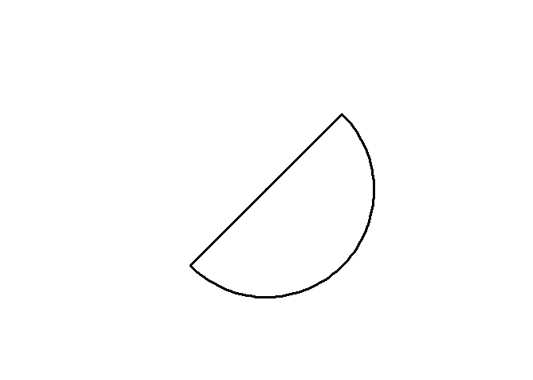

```r
draw(semi.circle.inv())
```

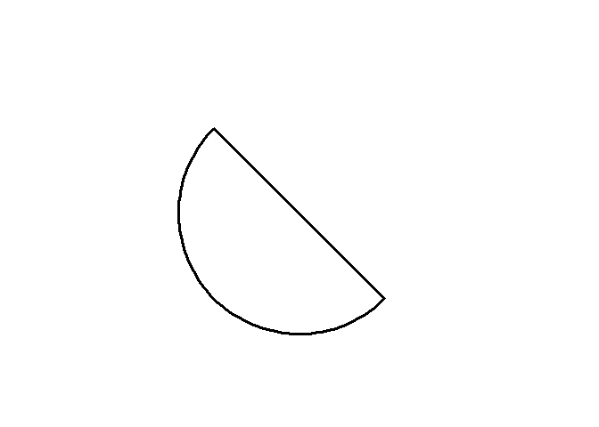

```r
draw(semi.circle.inv1())
```

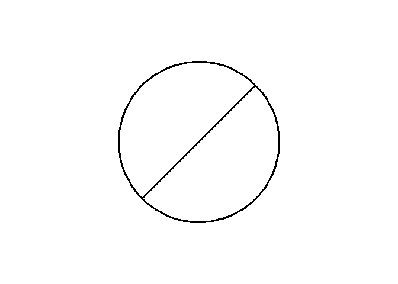

```r
draw(pie.2())
```

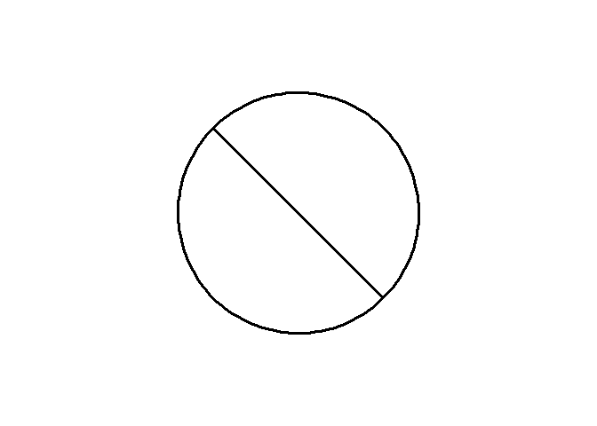

```r
draw(pie.2.inv())
```

NB: per `pie.2` e `pie.2.inv` esiste anche la versione simple (`u.pie.2`, `pie.2.inv`)

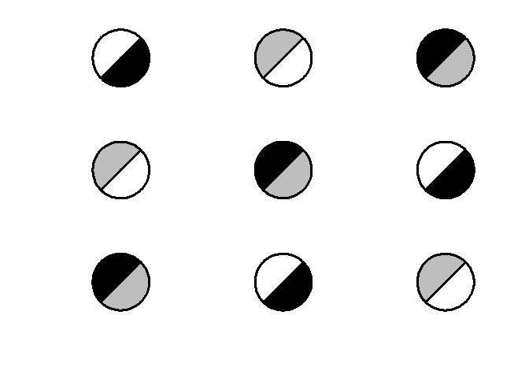

```r
M1<-apply(Raven(pie.2(),
                "multifill","multifill"))
draw(M1)
```

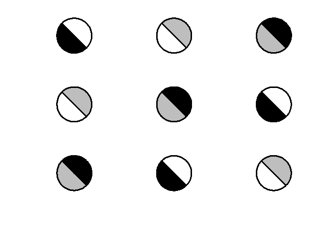

```r
M1<-apply(Raven(pie.2.inv(),
                "multifill","multifill"))
draw(M1)
```